# Week 2 Assignment

Mike

19 Juni 2019

This is an R Markdown document to show the solution as well as the results of the assignment from week 2.

### Do some cleaning and package loading stuff and load the necessary data set

```r
rm(list=ls())
library("dplyr")
library("ggplot2")
library("Hmisc")
setwd("C:/User/Reproducible_Research/week2")
activity <- read.csv2("activity.csv",sep=",")
head(activity)
```

```
##   steps       date interval
## 1    NA 2012-10-01        0
## 2    NA 2012-10-01        5
## 3    NA 2012-10-01       10
## 4    NA 2012-10-01       15
## 5    NA 2012-10-01       20
## 6    NA 2012-10-01       25
```

### Date transformation

```r
activity$date <- as.Date(activity$date)
```

## Question 1: What is mean total number of steps taken per day?

Missing values (NAN´s) will be ignored. The task is divided into 3 different steps:

### Calculate the total number of steps taken per day

```r
total_steps_per_day <- activity %>% select(steps, date, interval) %>% group_by(date) %>%
                       summarise(total_steps = sum(steps))
head(total_steps_per_day)
```

```
## # A tibble: 6 x 2
##   date       total_steps
##   <date>           <int>
## 1 2012-10-01          NA
## 2 2012-10-02         126
## 3 2012-10-03       11352
## 4 2012-10-04       12116
## 5 2012-10-05       13294
## 6 2012-10-06       15420
```

### Make a histogram of the total number of steps taken each day

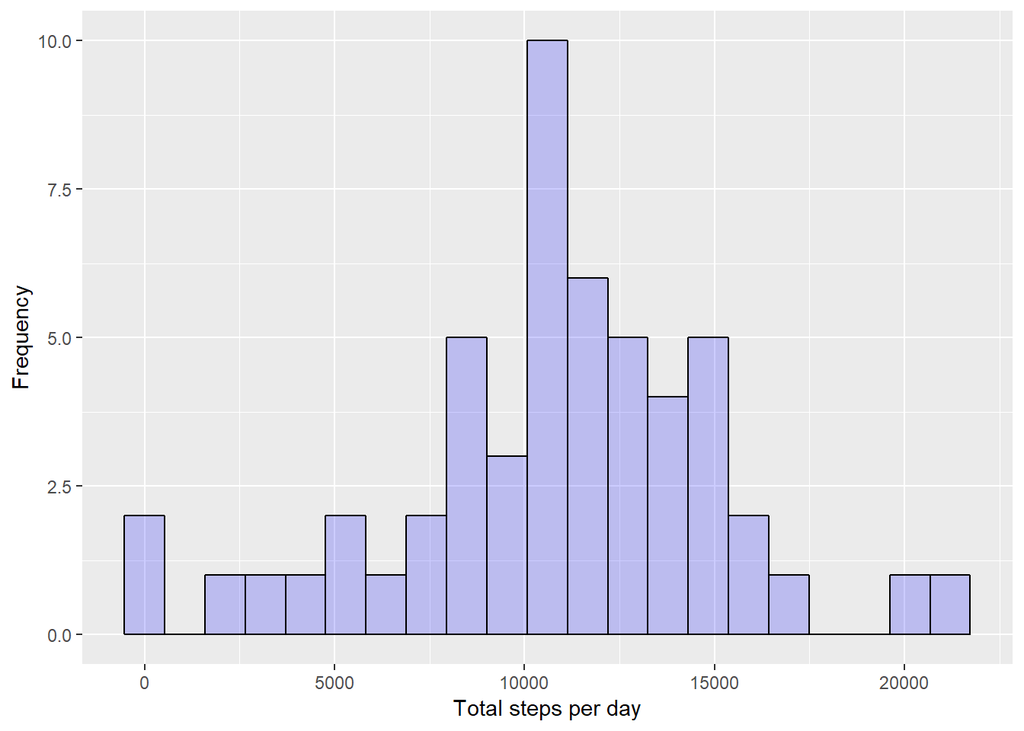

```r
qplot(total_steps_per_day$total_steps, geom="histogram", binwidth = 1060, xlab = "Total steps per day",
      ylab="Frequency", fill=I("blue"), col=I("black"), alpha=I(.2))
```

### Calculate and report the mean and median of the total number of steps per day

```r
mean(na.omit(total_steps_per_day$total_steps))
```

```
## [1] 10766.19
```

```r
median(na.omit(total_steps_per_day$total_steps))
```

```
## [1] 10765
```

## Question 2: What is the average daily activity pattern?

The task is divided into 2 different steps:

### Time series plot of the interval and average number of steps, averaged across days

```r
average_steps_per_interval <- (na.omit(activity)) %>% select(steps, date, interval) %>% group_by(interval) %>%
                               summarise(mean_steps = mean(steps))
head(average_steps_per_interval)
```

```
## # A tibble: 6 x 2
##   interval mean_steps
##      <int>      <dbl>
## 1        0     1.72
## 2        5     0.340
## 3       10     0.132
## 4       15     0.151
## 5       20     0.0755
## 6       25     2.09
```

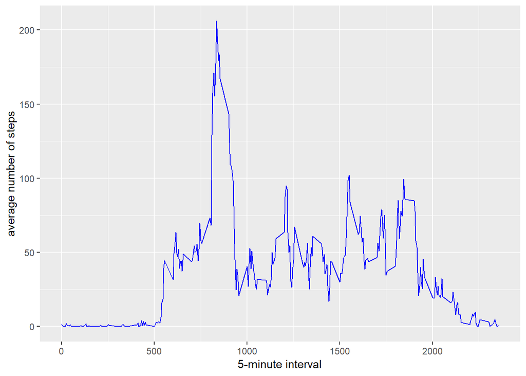

```r
ggplot(data=average_steps_per_interval, aes(x=interval, y=mean_steps)) + geom_line( col="blue") +
    xlab("5-minute interval") + ylab("average number of steps")
```

### Which 5-minute interval contains the maximum number of steps?

```r
maximum <- average_steps_per_interval[which(average_steps_per_interval$mean_steps == max(average_steps_per_interval$mean_steps)), ]
maximum_interval <- maximum$interval
print(maximum_interval)
```

```
## [1] 835
```

```r
maximum_steps <- maximum$mean_steps
print(maximum_steps)
```

```
## [1] 206.1698
```

## Task 3: Imputing missing values

The task is divided into 7 different steps:

### Calculate and report the total number of missing values in the dataset

```r
missing_values_steps <- sum(is.na(as.character(activity$steps)))
print(missing_values_steps)
```

```
## [1] 2304
```

```r
missing_values_date <- sum(is.na(as.character(activity$date)))
print(missing_values_date)
```

```
## [1] 0
```

```r
missing_values_interval <- sum(is.na(as.character(activity$interval)))
print(missing_values_interval)
```

```
## [1] 0
```

```r
missing_values_sum <- missing_values_steps + missing_values_date + missing_values_interval
print(missing_values_sum)
```

```
## [1] 2304
```

### Devise a strategy for filling in all of the missing values in the dataset

Since there is no further information, the missing values of “steps”" are replaced by the the mean value of all existing step data. This can be done relatively easily with the function “impute”.

### Create a new dataset equal to the original one but with the missing data filled in.

```r
activity_without_nan <- activity
activity_without_nan$steps <- impute(activity_without_nan$steps,fun=mean)
head(activity_without_nan)
```

```
##     steps       date interval
## 1 37.3826 2012-10-01        0
## 2 37.3826 2012-10-01        5
## 3 37.3826 2012-10-01       10
## 4 37.3826 2012-10-01       15
## 5 37.3826 2012-10-01       20
## 6 37.3826 2012-10-01       25
```

### Make a histogram of the total number of steps taken each day

```r
total_steps_per_day_without_nan <- activity_without_nan %>% select(steps, date, interval) %>% group_by(date) %>%  summarise(total_steps = sum(steps))
```

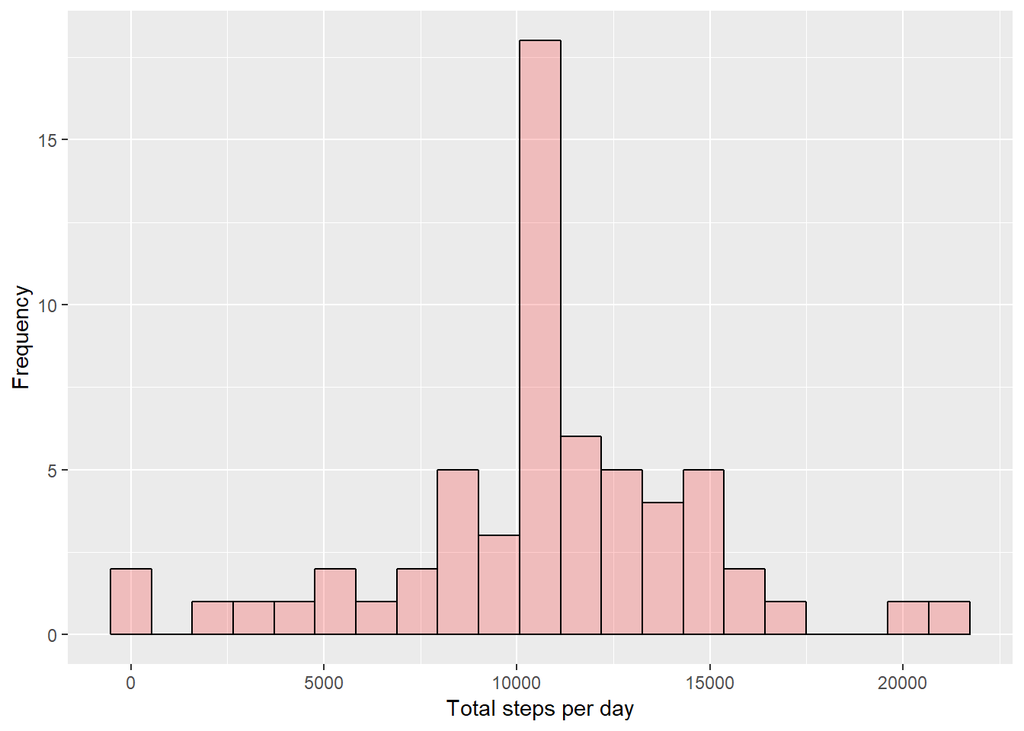

```r
qplot(total_steps_per_day_without_nan$total_steps, geom="histogram", binwidth = 1060, xlab = "Total steps per day",  ylab="Frequency", fill=I("red"), col=I("black"), alpha=I(.2))
```

### Calculate and report the mean and median total number of steps taken per day.

```r
mean_total_steps_without_na <- mean(total_steps_per_day_without_nan$total_steps)
print(mean_total_steps_without_na)
```

```
## [1] 10766.19
```

```r
median_total_steps_without_na <- median(total_steps_per_day_without_nan$total_steps)
print(median_total_steps_without_na)
```

```
## [1] 10766.19
```

### Do these values differ from the estimates from the first part of the assignment?

```r
mean_before_imputing <-  mean(na.omit(total_steps_per_day$total_steps))
print(mean_before_imputing)
```

```
## [1] 10766.19
```

```r
mean_after_imputing <-  mean(total_steps_per_day_without_nan$total_steps)
print(mean_after_imputing)
```

```
## [1] 10766.19
```

```r
median_before_imputing <-  median(na.omit(total_steps_per_day$total_steps))
print(median_before_imputing)
```

```
## [1] 10765
```

```r
median_after_imputing <-  median(total_steps_per_day_without_nan$total_steps)
print(median_after_imputing)
```

```
## [1] 10766.19
```

### What is the impact of imputing missing data on the estimates of the total daily number of steps?

The mean value is completly identical. The median value shows slight differences.

## Question 4: Are there differences in activity patterns between weekdays and weekends?

The task is divided into 2 different steps:

### Create a new factor variable in the dataset with two levels – “weekday” and “weekend”

```r
activity_without_nan$days <- weekdays(activity_without_nan$date)
activity_without_nan$week <- ""
activity_without_nan[activity_without_nan$days == "Samstag" | activity_without_nan$days == "Sonntag", ]$week <- "weekend"
activity_without_nan[!(activity_without_nan$days == "Samstag" | activity_without_nan$days == "Sonntag"), ]$week <- "weekday"
activity_without_nan <- (activity_without_nan) %>% select(steps, date, interval,days,week) %>% group_by(week, interval) %>% summarise(mean_steps = mean(steps))
print(activity_without_nan)
```

```
## # A tibble: 576 x 3
## # Groups:   week [2]
##    week    interval mean_steps
##    <chr>      <int>      <dbl>
##  1 weekday        0       7.01
##  2 weekday        5       5.38
##  3 weekday       10       5.14
##  4 weekday       15       5.16
##  5 weekday       20       5.07
##  6 weekday       25       6.30
##  7 weekday       30       5.61
##  8 weekday       35       6.01
##  9 weekday       40       4.98
## 10 weekday       45       6.58
## # ... with 566 more rows
```

### Make a panel plot containing a time series plot

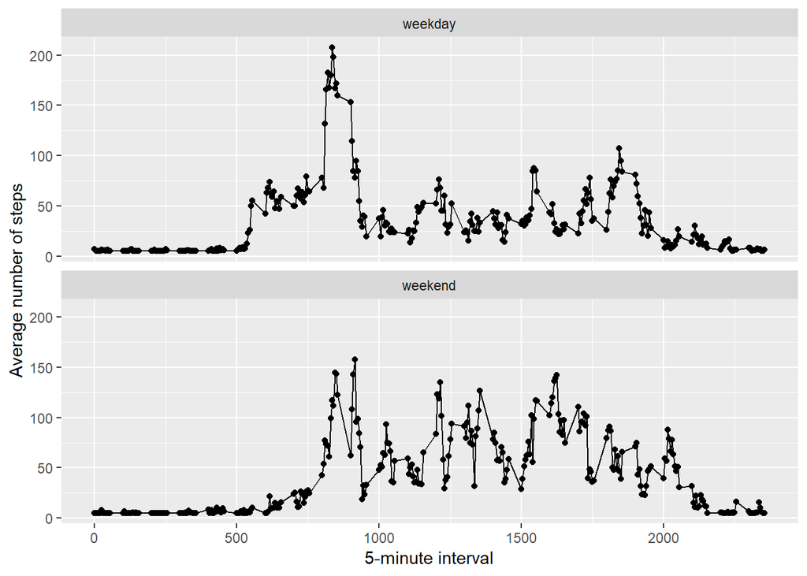

```r
qplot(interval,mean_steps,data=activity_without_nan) + geom_line() + facet_wrap(.~week,  ncol=1) +
xlab("5-minute interval") +
ylab("Average number of steps")
```